### LTER: Island vs Mainland

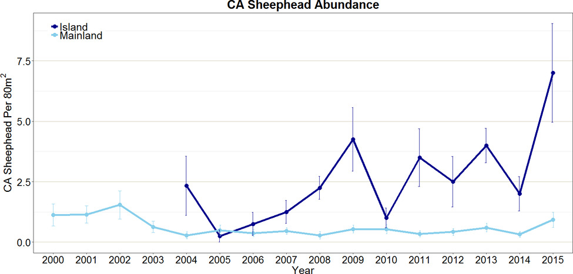

**Figure App.F.12.14.**. A figure showing the average number of California sheephead around two of the Channel Islands (dark blue) and on the mainland (light blue) from 2000 - 2015.

**Click for Details**

Average number (+/- standard error) of California sheephead *Semicossyphus pulcher* at two island (dark blue) and nine mainland (light blue) sites monitored by the Santa Barbara Channel Long-term Ecological Research (SBC LTER) program. Abundance appears to be increasing at the island sites compared to the mainland sites. Data source: SBC LTER; Figure: [R. Freedman/NOAA](https://channelislands.noaa.gov/contact/freedman.html)

### MARE: Density In/Out MPAs

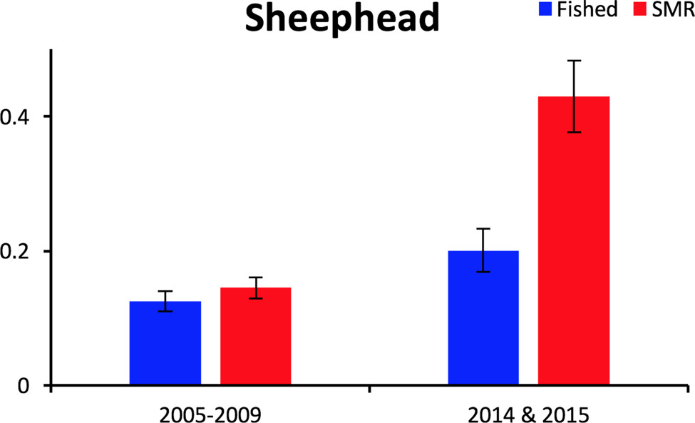

**Figure App.F.12.16.**. A figure showing the density of California sheephead inside fished (blue) and unfished (red) marine reserves around the Channel Islands.

**Click for Details**

Average density (per 100 m2 +/- SE) of California sheephead (*Semicossyphus pulcher*) at fished (blue) and unfished marine reserves (red) surveyed annually in two time periods 2005–2009 and 2014–2015. Density has increased since the baseline period, and the increase was more pronounced inside reserves as compared to fished sites. Figure: [MARE](https://www.maregroup.org/)